# Classificació atès al motiu de desplaçament dels conductors ferits en accidents de trànsit a Barcelona (2023)

Joan Manel Ramírez Jávega

18 Agost del 2024

# 1 Introducció i presentació de les dades

Donant continuïtat al treball ja realitzat en el marc de l’assignatura *Mineria de dades*, cursada durant el segon semestre del curs 2023-2024 del Màster de Ciència de Dades (Universitat Oberta de Catalunya) i podent-se consultar tant la [primera part](https://rpubs.com/ramirezjm/1210633) com la [segona part](https://rpubs.com/ramirezjm/1210635) en el repositori *RPubs*, ens proposem millorar-ne la modelització ja realitzada i escollir el model més addient per realitzar la imputació en la variable depenent “Es_mon_treball”. Finalment, també prepararem les dades per que es puguin representar les dades en una capa del programari *QGIS*. Atès que part de les tasques ja s’han presentat i comentat en les dues parts anteriors, evitarem repetir aquelles seccions amb codi que ja s’han detallat en els dos articles anteriorment referits.

En aquest article realitzarem les tasques d’estandarització, neteja i codificació pel conjunt de dades corresponent a aquells conductors dels qui constava en l’expedient obert per la Guàrdia Urbana de Barcelona que el seu motiu de desplaçament com *Es desconeix*. Atès a que la naturalesa repetitiva d’aquest fragment amb el ja detallat en la [primera part](https://rpubs.com/ramirezjm/1210633), s’evitarà repetir-lo de nou.

```r
maskDistDescon <- dades$Nom_districte == "Desconegut"
dadesDistDescon <- dades[maskDistDescon, ]
dades_ <- dades[!maskDistDescon, ]

maskDistDescon <- dadesDesconegut$Nom_districte == "Desconegut"
dadesDistDescon <- dadesDesconegut[maskDistDescon, ]
dadesDesconegut_ <- dadesDesconegut[!maskDistDescon, ]

nMotiuConegut <- nrow(dades_)
nMotiuDesconegut <- nrow(dadesDesconegut_)
nConductors <- nMotiuConegut + nMotiuDesconegut
propMotiuConegut <- round((nMotiuConegut /nConductors) * 100, 3)
propMotiuDesconegut <- round((nMotiuDesconegut /nConductors) * 100, 3)

print(glue("Es prenen en consideració {nConductors} conductors en total, dels qui {nMotiuConegut} ({propMotiuConegut} %) sí
es coneix el motiu del seu desplaçament i d'altres {nMotiuDesconegut} ({propMotiuDesconegut} %) se'n
desconeix el motiu del seu desplaçament."))
```

```
## Es prenen en consideració 5019 conductors en total, dels qui 2823 (56.246 %) sí
## es coneix el motiu del seu desplaçament i d'altres 2196 (43.754 %) se'n
## desconeix el motiu del seu desplaçament.
```

En canvi sí resulta rellevant observar que, a diferència de la tasca de codificació realitzada en la [segona part](https://rpubs.com/ramirezjm/1210635) de la variable “Es_ocupacional”, que identifica si el moment que va tenir lloc l’accident era durant una franja horària amb un elevada proporció de desplaçament relacionats amb el món del treball o no en dies laborables, ara actualitzarem amb els resultats de l’*Enquesta de mobilitat en dia feiner 2023* corresponents a l’any 2023 que fan referència a les franjes horàries i el motiu del desplaçament (INSTITUT METRÒPOLI, 2023: 49), tot i que a partir d’aquesta evidència en contrast a les conclusions de l’estudi esmentat, trobem rellevant el nombre de desplaçaments relacionats amb el món del treball durant la franja des de les 5 fins les 16 hores - ambdues franges incloses-:

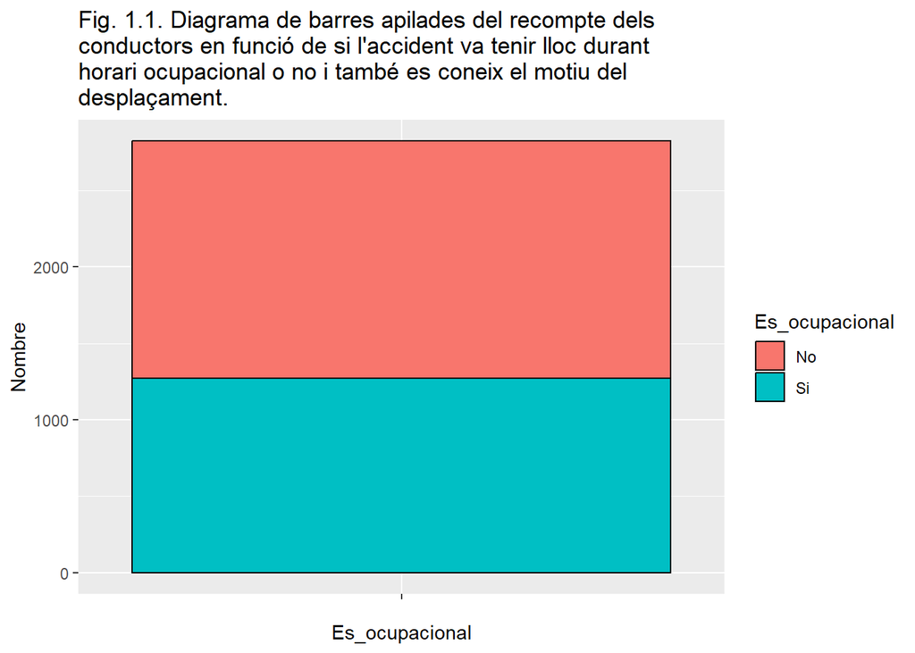

```r
dades_["Es_ocupacional"] <- "No"
horaOcupacional <- c(5, 6, 7, 8, 9, 10, 11, 12, 13, 14, 15, 16)
maskHorari <- dades_$Hora_dia %in% horaOcupacional
maskLaborable <- dades_$Es_laborable == "Si"
dades_$Es_ocupacional[maskHorari & maskLaborable] <- "Si"

aggEs_ocupacional <- aggregate(dades_$Numero_expedient,
                       by=dades_["Es_ocupacional"], FUN=length)

ggplot(aggEs_ocupacional, aes(x="", y=x, fill=Es_ocupacional)) +
  geom_bar(width = 1, stat = "identity", color = "black") +
  ggtitle(glue("Fig. 1.1. Diagrama de barres apilades del recompte dels
conductors en funció de si l'accident va tenir lloc durant
horari ocupacional o no i també es coneix el motiu del
desplaçament.")) +
  xlab(glue("Es_ocupacional")) +
  ylab("Nombre")
```

```r
nAccidents <- length(unique(dades_$Numero_expedient))
nNo_Es_ocupacional <- aggEs_ocupacional[1, 2]
propNo_Es_ocupacional <- round((nNo_Es_ocupacional / nMotiuConegut) * 100, 3)
nSi_Es_ocupacional <- aggEs_ocupacional[2, 2]
propSi_Es_ocupacional <- round((nSi_Es_ocupacional / nMotiuConegut) * 100, 3)

print(glue("Del conjunt de conductors dels qui sí es coneix el motiu del seu desplaçament,
{nSi_Es_ocupacional} ({propSi_Es_ocupacional} %) es desplaçaven durant horari ocupacional i altres {nNo_Es_ocupacional}
({propNo_Es_ocupacional} %), comptant-se {nAccidents} accidents en total."))
```

```
## Del conjunt de conductors dels qui sí es coneix el motiu del seu desplaçament,
## 1272 (45.058 %) es desplaçaven durant horari ocupacional i altres 1551
## (54.942 %), comptant-se 2561 accidents en total.
```

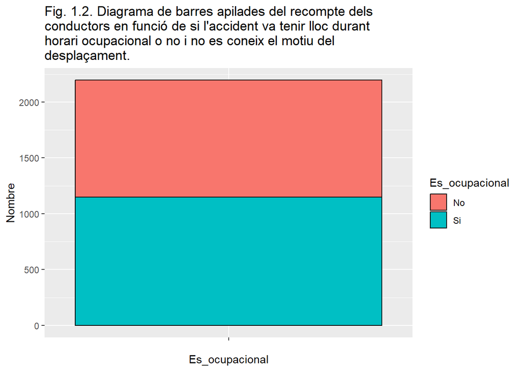

```r
dadesDesconegut_["Es_ocupacional"] <- "No"
horaOcupacional <- c(5, 6, 7, 8, 9, 10, 11, 12, 13, 14, 15, 16)
maskHorari <- dadesDesconegut_$Hora_dia %in% horaOcupacional
maskLaborable <- dadesDesconegut_$Es_laborable == "Si"
dadesDesconegut_$Es_ocupacional[maskHorari & maskLaborable] <- "Si"

aggEs_ocupacional <- aggregate(dadesDesconegut_$Numero_expedient,
                       by=dadesDesconegut_["Es_ocupacional"], FUN=length)

ggplot(aggEs_ocupacional, aes(x="", y=x, fill=Es_ocupacional)) +
  geom_bar(width = 1, stat = "identity", color = "black") +
  ggtitle(glue("Fig. 1.2. Diagrama de barres apilades del recompte dels
conductors en funció de si l'accident va tenir lloc durant
horari ocupacional o no i no es coneix el motiu del
desplaçament.")) +
  xlab(glue("Es_ocupacional")) +
  ylab("Nombre")
```

```r
nAccidents <- length(unique(dadesDesconegut_$Numero_expedient))
nNo_Es_ocupacional <- aggEs_ocupacional[1, 2]
propNo_Es_ocupacional <- round((nNo_Es_ocupacional / nMotiuDesconegut) * 100, 3)
nSi_Es_ocupacional <- aggEs_ocupacional[2, 2]
propSi_Es_ocupacional <- round((nSi_Es_ocupacional / nMotiuDesconegut) * 100, 3)

print(glue("Del conjunt de conductors dels qui sí es coneix el motiu del seu desplaçament,
{nSi_Es_ocupacional} ({propSi_Es_ocupacional} %) es desplaçaven durant horari ocupacional i altres {nNo_Es_ocupacional}
({propNo_Es_ocupacional} %) no, comptant-se {nAccidents} accidents en total."))
```

```
## Del conjunt de conductors dels qui sí es coneix el motiu del seu desplaçament,
## 1150 (52.368 %) es desplaçaven durant horari ocupacional i altres 1046
## (47.632 %) no, comptant-se 2029 accidents en total.
```

Atès al resultat observable en les figures 1.1 i 1.2, es constata que la proporció de conductors ferits en accidents que van tenir lloc durant una franja horària ocupacional o no s’inverteix en el cas que es coneix o no també el motiu del seu desplaçament.